# Vignette for the final

SC19009

2019-12-27

# Overview

**SC19009** is a simple R package developed for the final of ‘Statistical Computing’ course which is implemented through the R package *Rcpp*. This package includes two functions both based on resampling techniques. The two functions are named, respectively, *BCa* (calculating BCa confidenceinterval for population mean) and *jack* (calculating jackknife estimator for population mean and estimated variance for the mean estimator). Besides, the vignette for the package also includes all homework answers assingned throughout the whole semester.

# Part 1: Introduction for the two functions

The compiled two functions are based on resampling techniques: jackknife and bootstrap and their extended application in point estimation and interval estimation. The estimator for population mean and its confidence interval are considered in the two functions.

## Function_1: BCa

The function *BCa* calculates BCa confidence interval for population mean in R.  
The source R code for *BCa* is as following:

```r
BCa<-function(x,alpha,B){
  n<-length(x)
  bar<-mean(x)

  bar.boot<-numeric(B)
  for (i in 1:B) {
    j<-sample(1:n,n,replace=TRUE)
    bar.boot[i]<-mean(x[j])
  }

  bar.jack<-(sum(x)-x)/(n-1)
  bar0.jack<-mean(bar.jack)

  z<-qnorm((1-alpha)/2)
  z0<-qnorm(mean(bar.boot<bar))
  alpha0<-sum((bar0.jack-bar.jack)^3)/(6*sum(abs(bar0.jack-bar.jack)^3))

  alpha1<-pnorm(z0+(z0+z)/(1-alpha0*(z0+z)))
  alpha2<-pnorm(z0+(z0-z)/(1-alpha0*(z0-z)))

  lb.BCa<-quantile(bar.boot,alpha1,names=FALSE)
  ub.BCa<-quantile(bar.boot,alpha2,names=FALSE)

  out<-c(lb.BCa,ub.BCa)
  names(out)<-c("lb","ub")
  return(out)
}
```

To implement *BCa*, input a vector composed of sample points, confidence level and number of bootstrap replicates. Corresponding output is a named vector representing the confidence interval.  
A simple implementation is as following:

```r
library(SC19009)
x<-rbeta(200,4,4)
BCa(x,0.95,500)
```

```
##        lb        ub
## 0.4680535 0.5062528
```

## Function_2: jack

The function *jack* conducts a jackknife estimation for population mean and the variance for the estimator in C++.  
The source C++ code for *jack* is as following:

```r
NumericVector jack(NumericVector x){
  int n=sizeof(x); double s=sum(x); double bar0=s/n;
  double bar[n]; double y[n]; double sum1=0; double sum2=0;

  for (int i=0;i<=n-1;i++){
    bar[i]=(s-x[i])/(n-1);
    sum1=sum1+bar[i];
  }

  double bar1=sum1/n;
  double jack=n*bar0-(n-1)*bar1;

  for (int i=0;i<=n-1;i++){
    double z=bar[i]-bar1;
    y[i]=z*z;
    sum2=sum2+y[i];
  }

  double var=(n-1)*sum2/n;

  NumericVector out= NumericVector::create(Named("jack",jack),Named("var",var));
  return (out);
}
```

To implement *jack*, input a vector composed of sample points. Corresponding output is a 2-dimension named vector, whose first element is the mean estimate: $\hat\mu$ and the second element is the estimated variance for the mean estimator: $\hat{Var}(\hat\mu)$.  
A simple implementation for *jack* is as following:

```r
y<-rnorm(500,4,4)
jack(y)
```

```
##      jack       var
## 5.2446801 0.4283644
```

# Part 2: All homework answers

# 2019-9-20

## Example 1 : texts

* An Introduction about tinytex derived from https://yihui.name/tinytex/: TinyTeX is a custom LaTeX distribution based on TeX Live that is small in size (150Mb on macOS/Linux and 220Mb on Windows) but functions well in most cases, especially for R users. If you run into the problem of missing LaTeX packages, it should be super clear to you what you need to do (in fact, R users won’t need to do anything). You only install LaTeX packages you actually need.

* A few packages applicable for reproducibility while using R: knitr, rmarkdown, rticles, xtable, devtools,

## Example 2 : figures

* I utilised three different functions to create diffrent graphics

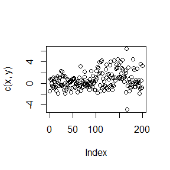

```r
x<-rnorm(100,mean=0,sd=1)
y<-rnorm(100,mean=1,sd=2)
plot(c(x,y))
```

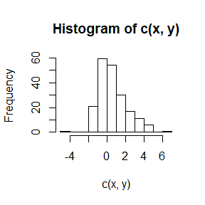

```r
hist(c(x,y))
```

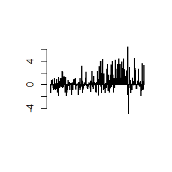

```r
barplot(c(x,y))
```

## Example 3 : tables

* Here’s a simple table composed of three person’s name and their age

```r
name<-c("Tom","Tony","Tomy")
age<-c(20,30,40)
table(name,age)
```

```
##       age
## name   20 30 40
##   Tom   1  0  0
##   Tomy  0  0  1
##   Tony  0  1  0
```

* The second table consists of a Poisson variable and its frequency with 100 samples

```r
x<-rpois(100,3)
ftable(x)
```

```
## x  0  1  2  3  4  5  6  7  8  9
##
##    2 19 19 23 17 10  6  1  1  2
```

# 2019-9-29

## 3.4

### (1) Basic idea

Through calculation , we can derive the distribution fuction of the objective density function , namely :
$$F(x)=1-e^{-x^{2} /\left(2 \sigma^{2}\right)} \quad, x \geq 0, \sigma>0.$$
Evidently , when $x\in[0,+\infty)$ , $F(x)$ is continuous and strictly increasing . Moreover , we can get its inverse funtion :
$$F^{-1}(y)=\sqrt{-2\sigma^{2} \ln (1-y)} \quad ,0 \leqslant y \leqslant 1, \sigma>0.$$
Hence , an intuitive way to generate random samples from this distribution is the inverse transform method .

### (2) Code and results

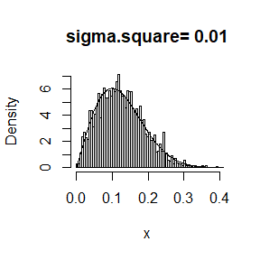

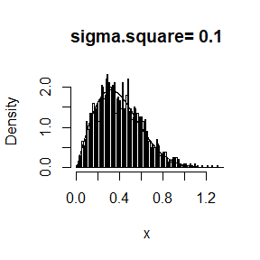

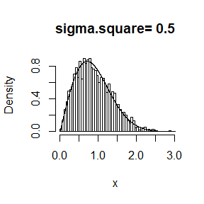

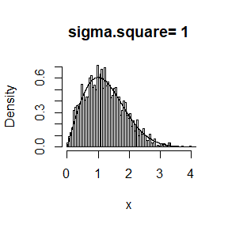

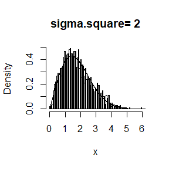

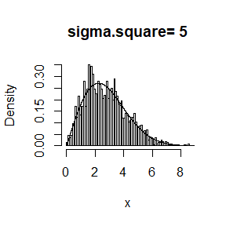

```r
# Define the function to generate samples with varing sigma^2
Inv.sample<-function(n,sigma.square) {
  u<-runif(n)
  y<-sqrt(-2*sigma.square*log(1-u))
  return(y)
}

# Generate samples
x<-matrix(nrow=2000,ncol=6)
sigma.square<-c(0.01,0.1,0.5,1,2,5)  ## Choose different sigma^2
for (i in 1:6) x[,i]<-Inv.sample(2000,sigma.square[i])

# Visualization of samples and theoretical density
for (i in 1:6) {
  hist(x[,i],prob=TRUE,breaks=100,xlab="x",main=paste("sigma.square=",sigma.square[i])) ## histogram
  y<-seq(0,10,0.001)
  lines(y,y*exp(-y^2/(2*sigma.square[i]))/sigma.square[i]) ## theoretical density curve
}
```

### (3) Result evaluation

According to the figures above , the histogram coincide well with the theoretical density curve after choosing different $\sigma^{2}$ therein . As $\sigma^{2}$ increases,the curve becomes flater .

## 3.11

### (1) Basic idea

Since the function to generate samples from normal distribution is available in R , considering the form of our objective distribution (mixture distibution) : $F(x)=p_{1} F_{1}(x)+\left(1-p_{1}\right) F_{2}(x)$ , an ideal way to generate random samples from $F$ is transformation method .

### (2) Code and results

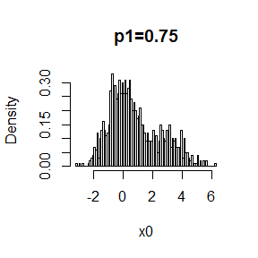

```r
# Define the function to generate samples with varying p1
Trans.sample<-function(p1) {
  x1<-rnorm(1000,mean=0,sd=1)
  x2<-rnorm(1000,mean=3,sd=1)
  r<-sample(c(1,0),1000,replace=TRUE,prob=c(p1,1-p1))
  x<-r*x1+(1-r)*x2
  return(x)
}

# Sampling with the given probabilty : p1=0.75
x0<-Trans.sample(0.75)
hist(x0,breaks=100,prob=TRUE,main="p1=0.75")
```

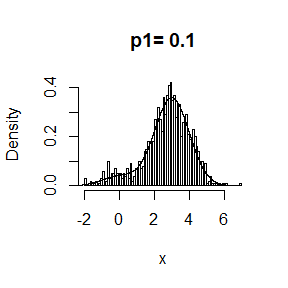

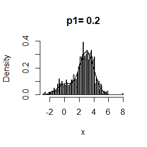

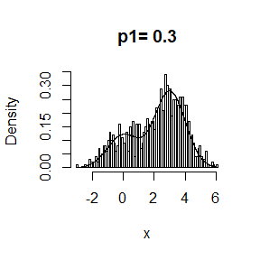

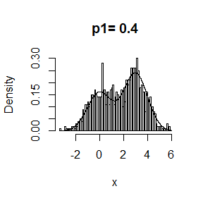

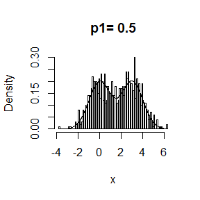

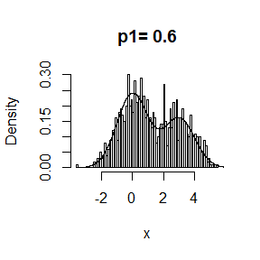

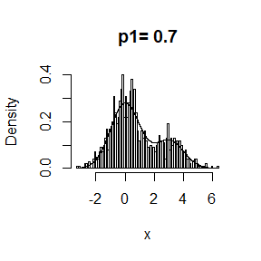

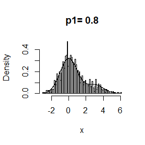

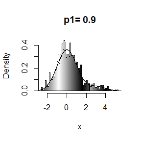

```r
# Sampling with different p1
p1<-seq(0.1,0.9,0.1)
x<-matrix(nrow=1000,ncol=9)
y<-seq(-3,6,0.001)
for (i in 1:9) {
  x[,i]<-Trans.sample(p1[i])
  hist(x[,i],breaks=100,prob=TRUE,xlab="x",main=paste("p1=",p1[i]))
  lines(y,p1[i]*dnorm(y,mean=0,sd=1)+(1-p1[i])*dnorm(y,mean=3,sd=1)) ## superimposing density
}
```

### (3) Conjecture

The sample from objective mixture distribution with $p_{1}$=0.75 is graphed in the first histogram above .  
As $p_{1}$ increases from $0$ to $1$ , the histogram deviates from right to left .  
Besides , it can be infered from a series of histogram where samples are derived with different $p_{1}$ that bimodal mixtures is produced when $p_{1}$=0.5 , which can be characterized by that the curve of $f$ has two peaks : $f(0)=f(3)=\max _{x} f(x)$ .

## 3.18

### (1) Basic idea

The definition of Wishart-distribution can be summarized as below :
Given
$$X=\left(\begin{array}{c}{X_{1}} \\ {\vdots} \\ {X_{n}}\end{array}\right)\ ;\ X_{1}, \ldots, X_{n} \ i.i.d \sim N_{d}(\mu, \Sigma)$$
then
$$W=X^{T} X \sim W_{d}(\Sigma, n)$$
A straight-forward method is to generate sample matrix $X$ via multivariate normal distribution , and calculate $W=X^{T} X$ . However , such method is inefficient because each sample entails $n$ samples from the population $N_{d}(\mu, \Sigma)$ , not to mention the calculation of W .
According to the requirement of the question , an appropriate way is Bartlett’s decomposition along with Choleski factorization .

### (2) Code

```r
# Define the function to generate Wishart samples with different n & d
Wis.sample<-function(d,n,sigma) {
  T<-matrix(0,nrow=d,ncol=d)
  if (n>(d+1) & (d+1)>1) {
    ## Common case when d>1
    if (d>1) {
      ### Generate lower triangular entries
      for (i in 2:d) {
        for (j in 1:i-1) T[i,j]<-rnorm(1,mean=0,sd=1)
      }

      ### Generate entries on the diagonal
      for (i in 1:d) {
        x<-rnorm(n-i+1,mean=0,sd=1)
        T[i,i]<-sqrt(sum(x^2))
      }

      ### Calculate the final result
      A=T%*%t(T)
      L<-t(chol(sigma)) #### Choleski factorization
      B=L%*%A%*%t(L)
      return(B)
    }
    ## Special case when d=1
    else {
      x<-rnorm(n,mean=0,sd=sigma)
      B<-sum(x^2)
      return(B)
    }
  }
  else warning("Input Error")
}
```

### (3) Output test

To test if this function is applicable , I try sampling with it :

```r
# General samples
set.seed(123) ## Omit this line to generate different samples if necessary
sigma<-matrix(c(1.2,.8,.8,.8,1.3,.8,.8,.8,1.4),nrow=3,ncol=3)
X1<-Wis.sample(3,5,sigma)

# Special sample with d=1
set.seed(1234)
sigma0<-5
X2<-Wis.sample(1,3,sigma0)

# Output
print(X1)
```

```
##          [,1]     [,2]     [,3]
## [1,] 6.509584 3.825510 4.319123
## [2,] 3.825510 3.628696 3.152061
## [3,] 4.319123 3.152061 6.040747
```

```r
print(X2)
```

```
## [1] 67.74968
```

Both two cases satisfy that $n>d+1>1$ . (The original statement in the book is that $n>d+1\geq1$ , but $d=0$ is meaningless .)
For simplicity , I set the matrix $\Sigma$ as :
$$\sum=\left(\begin{array}{ccc}{1.2} & {0.8} & {0.8} \\ {0.8} & {1.3} & {0.8} \\ {0.8} & {0.8} & {1.4}\end{array}\right)$$
It’s easy to verify that $\Sigma$ is symmetric and (semi) positive definite through its eigenvalues , thus it can be defined as a covariance matrix . In other words , $X1$ conforms to the definition of Wishart distribution .
We can tell from the output that the sampling process is functioning .

# 2019-10-11

## 5.1

### (1) Basic idea

The object integral can be written as :
$$\int_{0}^{\pi/3}\operatorname{sin}t\ dt=\int_{0}^{\pi/3}\frac{\pi\operatorname{sin}t}{3}\frac{3}{\pi}\ dt$$
Without considering variance reduction , the estimate of it can be obtained through simple Monte Carlo integration :
$$\hat{\theta}=\frac{1}{n}\sum\limits_{i=1}^n\frac{\pi\operatorname{sin}(x_i)}{3}$$
where $x_i$ is generated from the population $U(0,\frac{\pi}{3})$ , $i=1,2,\ldots,n$ .
Through computation , the exact value of the integral is $1-\operatorname{cos}(\pi/3)$ .

### (2) Code and output

```r
set.seed(1)
x<-runif(10000,0,pi/3)
MC<-mean(pi*sin(x)/3) # Monte Carlo integration
I<-1-cos(pi/3) # Exact value
print(c(MC,I))
```

```
## [1] 0.4997336 0.5000000
```

### (3) Comparison

As shown above , the estimate of $\theta=\int_{0}^{\pi/3}\operatorname{sin}\ t\ dt$ is $\hat{\theta}=$ 0.4997336 , while its exact value is $\theta=0.5$ .  
The precision of the estimate is ideal .

## 5.10

### (1) Basic idea

For the integrated function : $f(x)=\frac{e^{-x}}{1+x^2}$ , $f'(x)=\frac{(1-x)^2e^{-x}}{(1+x^2)^2} > 0\ ,\ x \in (0,1)$
So , $f$ is strictly increasing in $(0,1)$ . Thus , for a random variable $X$ , $f(X)$ and $f(1-X)$ are negatively correlated .
According to antithetic variables method (required by the question) , after generating $n$ random numbers $x_1\ ,\ldots,\ x_n$ from $U(0,1)$ , the estimate of $\theta=\int_{0}^1 \frac{e^{-x}}{1+x^2}dx$ is :
$$\hat{\theta}=\frac{1}{2n}\sum\limits_{i=1}^n[\frac{e^{-x_i}}{1+x_i^2}+\frac{e^{-(1-x_i)}}{1+(1-x_i)^2}]$$

### (2) Code and result

```r
set.seed(2)
x<-runif(10000,0,1)
y<-1-x
f<-function(x){
  y<-exp(x)/(1+x^2)
  return(y)
}
MC0<-mean(f(x))
MC<-mean(f(x)+f(y))/2
print(c(MC0,MC))
```

```
## [1] 1.271360 1.270268
```

```r
print(c(var(f(x)),var((f(x)+f(y))*0.5),100-100*var((f(x)+f(y))*0.5)/var(f(x))))
```

```
## [1]  0.010637741  0.001788511 83.187112467
```

## 5.15

### (1) Basic idea

The framework of the estimation is already given in Example 5.10 and Example 5.13 , but the original way to obtain subintervals in 5.13 is wrong . A rational modification is :
1. Considering the selected importance function :
$$f_3(x)=\frac{e^{-x}}{1-e^{-1}}\ ,\ 0<x<1$$
Then :
$$F_3(x)=\frac{1-e^{-x}}{1-e^{-1}}\ ,\ 0<x<1$$
Divide the inteval $(0,1)$ into five subintervals :
$$I_j=(F_3^{-1}(\frac{j}{5})\ ,\ F_3^{-1}(\frac{j+1}{5}))\ ,\ j=0,1,\ldots,4$$
The conditional density function of the population $X\sim F_3$ on each subinterval $I_j$ is
$$g_j(x):=f_{X|I_j}(x)=\frac{f_{X,I_j}(x)}{P(X\in I_j)}=\frac{\frac{e^{-x}}{1-e^{-1}}}{1/5}=\frac{5e^{-x}}{1-e^{-1}}$$
2. It can be derived that :
$$G_j(x)=\frac{5(1-e^{-x})}{1-e^{-1}}-j\ ,\ x\in I_j$$
$$G_j^{-1}(y)=-\operatorname{ln}(1-\frac{(1-e^{-1})(y+j)}{5})\ ,\ y\in [0,1]$$
3. Generate $5\times m$ samples $X_i^j \sim U(0,1)\ ,\ j=0,1,\ldots,4\ ,i=1,2,\ldots,m$ . According to inverse transform method , $Y_i^j=G_j^{-1}(X_i^j)\sim G_j$ .
4. For the integrated function $f(x)=\frac{e^{-x}}{1+x^2}$ , the estimation of $\theta=\int_{0}^1 \frac{e^{-x}}{1+x^2}dx$ is
$$\hat{\theta}^{SI}=\frac{1}{5}\sum\limits_{j=0}^4[\frac{1}{m}\sum\limits_{x_i^j\in I_j} \frac{f(F_3^{-1}(x_i^j))}{g_j(F_3^{-1}(x_i^j))}]$$

### (2) Code and output

```r
f<-function(x){          # Integrated function f
  y<-exp(-x)/(1+x^2)
  return(y)
}

g<-function(x,j){          # Inverse function of Gj
  y<--log(1-(1-exp(-1))*(x+j-1)/5)
  return(y)
}

h<-function(x){          # Density function of samples
  y<-5*exp(-x)/(1-exp(-1))
  return(y)
}

set.seed(3)
x<-y<-matrix(nrow=2000,ncol=5)
for (j in 1:5) {
  x[,j]<-runif(2000,0,1)
  y[,j]<-g(x[,j],j) # Random numbers from population Gj
}
z<-f(y)/h(y)   # Integrated items
I<-colMeans(z) # Integration on each subinterval
MC<-sum(I) # theta.hat
sd<-sd(z)  # standard variance of integrated items
k<-100*(1-sd/0.0970314) # Percentage of reduction in standard variance
print(c(MC,sd,k))
```

```
## [1]  0.52511475  0.01931496 80.09411802
```

### (3) Comparison

According to the textbook , through importance sampling , the estimation of $\theta=\int_{0}^1 \frac{e^{-x}}{1+x^2}dx$ with the importance function $f_3(x)=\frac{e^{-x}}{1-e^{-1}}\ ,\ 0<x<1$ is $\hat{\theta}=0.5257801$ . The estimated standard error is 0.0970314 .  
Under stratified importance sampling method , the result is $\hat{\theta}=$ 0.5251147 , $sd=$ 0.019315 . The standard variance of the integrated terms is reduced about 80.094118% .

# 2019-10-18

## 6.5

### (1) Basic idea

Given confidence level $1-\alpha$ , the $t$-interval for the mean of a (normal) population is defined as :
$$(\bar{x}-\frac{t_{\frac{\alpha}{2}}(n-1)S_x}{\sqrt{n}},\bar{x}+\frac{t_{\frac{\alpha}{2}}(n-1)S_x}{\sqrt{n}})$$
where $n$ is the sample size , $\bar{x}$ is the mean of sample , $S_x$ is the sample standard deviation , $t_{\frac{\alpha}{2}}(n-1)$ represents the upper $\frac{\alpha}{2}$-quantile of $t$ distribution with $df=n-1$
As the population is already known that $X\sim \chi^2(2)$ , let $\theta=EX=2$ , for this confidence interval , the estimate of its coverage probability $P(\hat{\theta}_1<\theta<\hat{\theta}_2)$ is
$$\hat{P}=\frac{1}{m} \sum\limits_{j=1}^m I(\hat{\theta}_1^{(j)}<\theta<\hat{\theta}_2^{(j)})$$
where $(\hat{\theta}_1^{(j)},\hat{\theta}_2^{(j)})$ is the confidence interval of $\theta$ in the j$th$ MC experiment .

### (2) Code and output

```r
# t-interval
n<-20 # Required sample size
a<-0.05 # alpha
m<-10000 # Times to repeat MC experiment
I1<-c()
for (i in 1:m) {
  x<-rchisq(n,2)
  CI<-mean(x)+c(qt(a/2,n-1)*sd(x)/sqrt(n),-qt(a/2,n-1)*sd(x)/sqrt(n)) # Confidence interval
  I1[i]<-2<CI[2]&&2>CI[1]
}
p1.hat<-mean(I1)

# Simulation based on example 6.4
I2<-c()
for (i in 1:m){
  x<-rnorm(n,0,2)
  UCL<-(n-1)*var(x)/qchisq(a,n-1)
  I2[i]<-4<UCL
}
p2.hat<-mean(I2)
cbind(p1.hat,p2.hat)
```

```
##      p1.hat p2.hat
## [1,] 0.9228 0.9513
```

### (3) Comparison to Example 6.4

According to the output , the estimate of $P(\hat{\theta}_1<\theta<\hat{\theta}_2)$ is $\hat{P}=$ 0.9228 , which is a little lower than the confidence level $1-\alpha=0.95$ .  
In the simulation result of Example 6.4 , the estimated coverage probability is $\hat{P}=$ 0.9513 , which roughly equals to the confidence level .  
Hence the results above substantiated that whether the distribution of sample population is identical to the theoriotical one has (significant) effect on the coverage probabilty (the real confidence level) .

## 6.6

### (1) Basic idea

The definition of sample skewness of a population $X$ with sample $X_1,\ldots,X_n$ is
$$\sqrt{b_{1}}=\frac{\frac{1}{n} \sum_{i=1}^{n}\left(X_{i}-\bar{X}\right)^{3}}{\left(\frac{1}{n} \sum_{i=1}^{n}\left(X_{i}-\bar{X}\right)^{2}\right)^{3 / 2}}$$
In the answer below , samples to calculate skewnesses are generated form population $N(0,1)$ . According to formula (2.14) , under normality approximation , the standard error of the estimated $\alpha$-quantiles is
$$sd(\sqrt{b_{1}}_\alpha)=\sqrt\frac{\alpha(1-\alpha)}{nf(x_\alpha)^2}$$
where $f$ is the density function of $N(0,6/n)$ .
In each MC experiment , generate $n\times k$ normal samples to calculate $k$ skewnesses $\sqrt{b_1}_i\ ,\ i=1,\ldots,k$ .
Then , calculate the quatiles of skewnesses : $\hat{q}_{\alpha}^{(j)}\ ,\ j=1,\ldots,m$ .
Repeat MC experiment for $m$ times , and the MC estimate for each quantile is
$$\hat{q}_\alpha^{MC}=\frac{1}{m}\sum\limits_{j=1}^m\hat{q}_\alpha^{(j)}$$

### (2) Code and output

```r
# Sampling
n<-50 # Sample size to calculate skewness
k<-300 # Number of skewnesses to calculate their quantile
m<-10000 # Times to repeat MC experiment

a<-c(0.025,0.05,0.95,0.975) # alpha of quantiles

moment<-function(x,n){  # Function to calculate central moment
  y<-mean((x-mean(x))^n)
  return(y)
}

quantile.sk<-function(n,k){ # Function to calculate the quantile of skewness
  x<-matrix(nrow=k,ncol=n)
  skewness<-numeric(k)

  for (i in 1:k) {
    x[i,]<-rnorm(n,0,1) # Samples to calculate skewness
    skewness[i]<-moment(x[i,],3)/(moment(x[i,],2)^1.5)
  }
  q.est<-quantile(skewness,a) # Quantiles of skewness
  return(q.est)
}

q.est<-matrix(nrow=m,ncol=4)
for (j in 1:m) q.est[j,]<-quantile.sk(n,k) # m times of MC experiments for m quantiles

# Estimation
sd.sample<-apply(q.est,2,sd) # Actual standard error of quantiles
sd.formula<-sqrt(a*(1-a)/(n*dnorm(qnorm(a,0,sqrt(6/n)),0,sqrt(6/n))^2)) # Standard error calculated with the formula
rbind(sd.sample,sd.formula)
```

```
##                  [,1]       [,2]       [,3]       [,4]
## sd.sample  0.05434788 0.04221437 0.04217648 0.05429742
## sd.formula 0.13086697 0.10352462 0.10352462 0.13086697
```

```r
q.hat<-colMeans(q.est) # MC estimates of quantiles
q.norm<-qnorm(a,0,sqrt(6/n)) # Large sample approximation
rbind(q.hat,q.norm)
```

```
##              [,1]       [,2]      [,3]      [,4]
## q.hat  -0.6362521 -0.5279729 0.5274298 0.6356341
## q.norm -0.6789514 -0.5697940 0.5697940 0.6789514
```

# 2019-11-1

## 6.7

### (1) Basic idea

Classical skewness test for symmetricity can be characterized as:
$$H_0:\sqrt{\beta _1}=0\longleftrightarrow H_1:\sqrt{\beta _1}\neq0$$

While in this question the test is applied to test normality:
$$H_0:X\sim N(\mu,\sigma^2)\longleftrightarrow H_1:X\nsim N(\mu,\sigma^2)$$
And the test statistic is still sample skewness $\sqrt{b_1}$. Under normality assumption (namely, $H_0$), $\sqrt{b_1} \stackrel{d}\rightarrow N(0,6/n)$ as $n\rightarrow \infty$
Thus, having fixed significance level $\alpha$ , reject $H_0$ if $|\sqrt{b_1}|>z_{\alpha/2}(0,6/n)$, where $z_{\alpha/2}(0,6/n)$ represents the upper $\alpha/2$ quantile for $N(0,6/n)$

The power of the test against non-normal population can be estimated through Monte Carlo experiment.  
For simplicity, target parameter $\alpha$ for both Beta$(\alpha,\alpha)$ and $v$ for $t(v)$ range within {5,10,15,20,25}.

### (2) Code and output

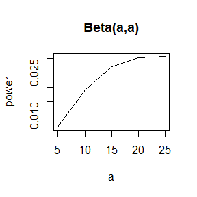

```r
# Sample skewness function
sk<-function(x){
  m3<-mean((x-mean(x))^3)
  m2<-mean((x-mean(x))^2)
  y<-m3/m2^1.5
  return(y)
}

# Generate sample from Beta and t
n<-200 # Sample size
m<-5000 # Replication of MC experiment
theta<-c(5,10,15,20,25) # Parameters

p1<-p2<-numeric(5)
for (i in theta){
  R1<-R2<-numeric(m)
  for (j in 1:m){
    x1<-rbeta(n,i,i)
    x2<-rt(n,i)
    b1<-sk(x1)
    b2<-sk(x2)
    z<-qnorm(0.975,0,sqrt(6/n))
    R1[j]<-mean(abs(b1)>z)
    R2[j]<-mean(abs(b2)>z)
  }
  p1[i/5]<-mean(R1)
  p2[i/5]<-mean(R2)
}

# Power curve
plot(theta,p1,xlab="a",ylab="power",main="Beta(a,a)",type="l")
```

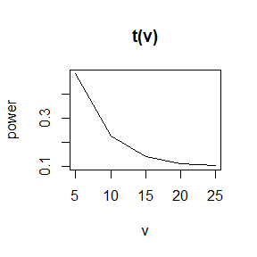

```r
plot(theta,p2,xlab="v",ylab="power",main="t(v)",type="l")
```

### (3) Result comment

According to the result, under $Beta(\alpha,\alpha)$ distribution, the power is quite low but gradually increasing with $\alpha$. While for $X\sim t(v)$, the power is much larger but decreasong with $v$.  
The empirical powers of the test in both two cases are much different. It can be infered that the asymptotic distribution of $\sqrt{b_1}$ deviates much form $N(0,6/n)$ under $t$ distribution, while not the same for $Beta$ distribution. Hence, we can conclude that the test is not applicable for all sample distribution.

## 6.A

### (1) Basic idea

Denote the mean of a population as $\mu$ , the $t$-test for whether $\mu=\mu_0$ can be characterized as:
$$H_0:\mu=\mu_0\longleftrightarrow H_1:\mu\neq\mu_0$$
Consider a test statistic:
$$T=\frac{\sqrt{n}(\bar{X}-\mu_0)}{S_X}$$
where $S_X=\sqrt{\frac{1}{n-1}\sum\limits_{i=1}^n(X_i-\bar{X})^2}$
Under normality assumption and $H_0$ , $T\sim t(n-1)$
Fix significance level $\alpha$ , reject $H_0$ if $|t|>t_{\alpha/2}(n-1)$
When sampling from different populations, the empirical type I error can be estimated respectively through Monte Carlo experiment.

### (2) Code and output

```r
m<-10000 # Replications of MC experiment
n<-100 # Sample size in each MC experiment
u<-1 # Population means are equivalent

# Chisq(1)
error.C<-replicate(m,expr={
  x<-rchisq(n,1)
  t<-sqrt(n)*(mean(x)-u)/sd(x)
  reject<-(abs(t)>qt(0.975,n-1))
})
Chi.rate<-mean(error.C)

# U(0,2)
error.U<-replicate(m,expr={
  x<-runif(n,0,2)
  t<-sqrt(n)*(mean(x)-u)/sd(x)
  reject<-(abs(t)>qt(0.975,n-1))
})
U.rate<-mean(error.U)

# Exp(1)
error.E<-replicate(m,expr={
  x<-rexp(n,1)
  t<-sqrt(n)*(mean(x)-u)/sd(x)
  reject<-(abs(t)>qt(0.975,n-1))
})
Exp.rate<-mean(error.E)

cbind(Chi.rate,U.rate,Exp.rate)
```

```
##      Chi.rate U.rate Exp.rate
## [1,]   0.0649 0.0523   0.0578
```

### (3) Result comment

According to the result, in each case, the empirical Type I error is only slightly different form nominal level, which substantiates that the $t$-test is robust to mild departures from normality.

## Discussion

Consider a single parameter hypothesis test problem :
$$H_0^*:\theta\in\Theta_0\longleftrightarrow H_1^*:\theta\in\Theta_1$$
The power of a method is defined as
$$\beta=P(p\leq \alpha|H_1^*)$$
where $p$ represent the $p$-value of the test method, $\alpha$ is the significance level.

* To test if two test methods have different power, denote their $p$-value as $p_1$ , $p_2$ , the corresponding hypothesis test problem can then be characterized as
$$H_0:P(p_1\leq \alpha|H_1^*)=P(p_2\leq \alpha|H_1^*)\longleftrightarrow H_1:P(p_1\leq \alpha|H_1^*)\neq P(p_2\leq \alpha|H_1^*)$$
Intuitively, the essence of this test problem is to test if the conditional distribution function values of $p_1$ and $p_2$ are equivalent at $\alpha$, conditional on $H_1$.

* Moreover, the test problem can be interpreted as
$$H_0:E(I(p_1\leq\alpha)|H_1^*)=E(I(p_2\leq\alpha)|H_1^*)\longleftrightarrow H_1:E(I(p_1\leq\alpha)|H_1^*)\neq E(I(p_2\leq\alpha)|H_1^*)$$
Since $\alpha$ and $H_1^*$ are fixed, notice that $I(p_1\leq\alpha)\ ,\ I(p_2\leq\alpha)$ are independent and
$$I(p_1\leq\alpha)\sim B(1,P(p_1\leq\alpha|H_1^*))\ ,\ I(p_2\leq\alpha)\sim B(1,P(p_2\leq\alpha|H_1^*))$$
conditional on $H_1$, this is a test of mean between two Bernoulli populations.

* In this question, 10,000 MC experiments were conducted, each experiment gives two samples from two Bernoulli populations respectively. Since the sample size are quite large: n=10000, we can use large sample approximation for the test. In other word, we resort to Z-test.

* Hence, we have the ultimate result for this question:
$(1)$ Population:
$$X\sim B(1,\mu_1)\ ,\ Y\sim B(1,\mu_2)$$
where $\mu_1=P(p_1\leq\alpha|H_1^*)\ ,\ ,\mu_2=P(p_2\leq\alpha|H_1^*)$

$(2)$ Hypothesis test problem:
$$H_0:\mu_1=\mu_2\longleftrightarrow H_1:\mu_1\neq\mu_2$$

$(3)$ Test method: Z-test
Under $H_0$, the estimation for $\mu\stackrel{\Delta}=\mu_1=\mu_2$ is $\hat{\mu}=\frac{\sum_i X_i+\sum_j Y_j}{2n}=\frac{\bar{X}+\bar{Y}}{2}$.
According to CLT and Slutsky theorem, under $H_0$, the Z-test statistic:
$$Z=\sqrt{\frac{n\times n}{n+n}} \frac{\bar{X}-\bar{Y}}{\hat{\mu}(1-\hat{\mu})}=\sqrt{\frac{n}{2}} \frac{\bar{X}-\bar{Y}}{\hat{\mu}(1-\hat{\mu})}\stackrel{d}\longrightarrow N(0,1)\quad \text{as}\quad n\rightarrow\infty$$
Fix significance level $\alpha'=0.05$, reject $H_0$ if $|Z|>z_{\alpha'/2}$

$(4)$ Needed information:  
$n\ ,\ \bar{X}$ and $\bar{Y}$, which is already given in the question that $n=10000\ ,\ \bar{X}=0.651$ and $\bar{Y}=0.676$.

$(5)$ Test result:  
It can be calculated that $z=7.9177>1.96=z_{0.025}$, thus we reject $H_0$ and deem that the powers are different.

# 2019-11-8

## 7.6

### Code and result

```r
library(bootstrap)
x<-scor
Corr=cor(x) # Corrlation.hat
print(Corr)
```

```
##           mec       vec       alg       ana       sta
## mec 1.0000000 0.5534052 0.5467511 0.4093920 0.3890993
## vec 0.5534052 1.0000000 0.6096447 0.4850813 0.4364487
## alg 0.5467511 0.6096447 1.0000000 0.7108059 0.6647357
## ana 0.4093920 0.4850813 0.7108059 1.0000000 0.6071743
## sta 0.3890993 0.4364487 0.6647357 0.6071743 1.0000000
```

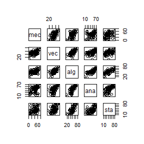

```r
plot(x)
```

```r
n<-nrow(x)
B<-1e4
Corr.star<-matrix(nrow=B,ncol=4)

for (i in 1:B) {
index<-sample(1:n,n,replace=TRUE)
x.star<-x[index,] # Bootstrap sample
Cor<-cor(x.star)
Corr.star[i,]<-c(Cor[1,2],Cor[3,4],Cor[3,5],Cor[4,5])
}

se.hat<-apply(Corr.star,2,sd)
knitr::kable(data.frame(value=se.hat,row.names=c("se12.hat","se34.hat","se35.hat","se45.hat")))
```

|  | value |
| --- | --- |
| se12.hat | 0.0763236 |
| se34.hat | 0.0486994 |
| se35.hat | 0.0596086 |
| se45.hat | 0.0684478 |

According to the correlation matrix, each pair of test scores are positive correlated to different extent, which accords with the scatterplot.  
Bootstrap estimates of the standard errors for these estimators are small, indicating that they are accurate estimator for the correlation coefficients of the population.

## 7.B

### (1) Basic idea

Consider normal population $X\sim N(0,1)$, its skewness is $\sqrt{\beta_1}_X=0$.  
While for $\chi^2$ population $Y\sim\chi^2(5)$, its skewness is $\sqrt{\beta_1}_Y=\frac{E(Y-EY)^3}{[Var(Y)]^{3/2}}=\sqrt{8/5}$  
Fix confidence level $1-\alpha=0.95$, calculation for empirical coverage rates is based on the two conclusions.

### (2) Code and result

```r
n<-100 # Sample size
M<-1e3 # Repeats for MC experiments
B<-1e3 # Times of Bootstrap experiments in each MC experiment

skew<-function(x){ # Function to calculate sample skewness
  m3<-mean((x-mean(x))^3)
  m2<-mean((x-mean(x))^2)
  y<-m3/m2^1.5
  return(y)
}

set.seed(1)
I.normal<-I.basic<-I.percentile<-matrix(nrow=M,ncol=2) # Coverage indicator

for (i in 1:M){
  x<-rnorm(n) # Normal population
  y<-rchisq(n,5) # Chisquare population
  skew.x<-skew(x)
  skew.y<-skew(y)
  skstar.x<-skstar.y<-numeric(B)

  for (j in 1:B){
    x.star<-sample(x,n,replace=TRUE)
    y.star<-sample(y,n,replace=TRUE)
    skstar.x[j]<-skew(x.star)
    skstar.y[j]<-skew(y.star)
  }

  x.n<-qnorm(0.975)*sd(skstar.x)
  y.n<-qnorm(0.975)*sd(skstar.y)

  x.b<-quantile(skstar.x,c(0.975,0.025))
  y.b<-quantile(skstar.y,c(0.975,0.025))

  I.normal[i,]<-c((skew.x-x.n)<=0 & 0<=(skew.x+x.n),
                  (skew.y-y.n)<=sqrt(8/5) & sqrt(8/5)<=(skew.y+y.n))

  I.basic[i,]<-c(2*skew.x-x.b[1]<=0 & 0<=2*skew.x-x.b[2],
                 2*skew.y-y.b[1]<=sqrt(8/5) & sqrt(8/5)<=2*skew.y-y.b[2])

  I.percentile[i,]<-c(x.b[2]<=0 & 0<=x.b[1],
                      y.b[2]<=sqrt(8/5) & sqrt(8/5)<=y.b[1])
}

prob.hat<-rbind(colMeans(I.normal),colMeans(I.basic),colMeans(I.percentile))
colnames(prob.hat)<-c("N(0,1)","Chisquare(5)")
out<-as.data.frame(prob.hat,row.names<-c("Normal","Basic","Percentile"))
knitr::kable(out)
```

|  | N(0,1) | Chisquare(5) |
| --- | --- | --- |
| Normal | 0.925 | 0.761 |
| Basic | 0.907 | 0.711 |
| Percentile | 0.933 | 0.737 |

It can be inferred from the result that the coverage probabilties of bootstrap confidence intervals are roughly close to nominal confidence level under normal population.  
While they may be of quite low reliability for $\chi^2$ population, as the empirical coverage rates deviate much from confidence level.

# 2019-11-15

## 7.8

### (1) Basic idea

The original question asked for the MLE of $\theta$, but it’s not available because the (joint) distribution of variables: $X_1,\ldots,X_5$ is completely unknown. Thus, in the answer below, $\hat{\theta}$ is obtained through sample covariance matrix.
Calculate ordinary estimation of $\theta$, denoted as $\hat{\theta}$.
Obtain the jackknife estimation of covariance matrix $\hat{\Sigma}_{(i)}$, and $\hat{\theta}_{(i)}$.
Calculate the jackknife estimation of bias and sd :
$$\hat{bias}_{jack}=(n-1)(\bar{\hat{\theta}}_{(\cdot)}-\hat{\theta})$$
$$\hat{sd}_{jack}=\sqrt{\frac{n-1}{n}\sum\limits_{i=1}^n(\bar{\hat{\theta}}_{(\cdot)}-\hat{\theta}_{(i)})^2}$$

### (2) Code and output

```r
library(bootstrap)
x<-scor
n<-nrow(x)
lambda.hat<-eigen(cov(x))$values
theta.hat<-lambda.hat[1]/sum(lambda.hat)

theta<-numeric(n)
for (i in 1:n) {
  Cov<-cov(x[-i,])
  lambda<-eigen(Cov)$values
  theta[i]<-lambda[1]/sum(lambda)
}

theta.jack<-mean(theta)
bias.jack<-(n-1)*(theta.jack-theta.hat)
var.jack<-var(theta)*(n-1)^2/n
sd.jack<-sqrt(var.jack)
out<-data.frame(bias.jack,sd.jack)

knitr::kable(out)
```

| bias.jack | sd.jack |
| --- | --- |
| 0.0010691 | 0.0495523 |

## 7.10

### (1) Basic idea

According to the text book, corresponding $\hat{\sigma}^2_{\epsilon}$’s for linear, quadratic and exponential model are respectively:
$$\hat{\sigma}^2_1=19.55644\ ,\quad \hat{\sigma}^2_2=17.85248\ ,\quad \hat{\sigma}^2_3=18.44188$$
Since the result of leave-one-out is always determinate, when choosing model by cross validation, we only need to conduct it on the newly required one: qubic polynomial model, and compare the output with the result given in the textbook.
However, when choosing model by adjusted $R^2$, we need to fit all four models and make comparison among the adjusted $R^2$ statstics of these models.

### (2) Code and output

```r
library(DAAG)
library(lattice)
attach(ironslag)
n<-length(magnetic)

e.qubic<-numeric(n)

for (i in 1:n){
  x<-chemical[-i]
  y<-magnetic[-i]
  L.qubic<-lm(y~x+I(x^2)+I(x^3))
  attach(L.qubic)
  e.qubic[i]<-magnetic[i]-(coefficients[1]+coefficients[2]*chemical[i]+coefficients[3]*chemical[i]^2+coefficients[4]*chemical[i]^3)
  detach(L.qubic)
}

d.qubic<-mean(e.qubic^2) # error.hat for qubic polynomial model

m.l<-lm(magnetic ~ chemical) # linear
m.q<-lm(magnetic ~ chemical + I(chemical^2)) # quadratic
m.e<-lm(log(magnetic) ~ chemical) # exponential
m.qubic<-lm(magnetic ~ chemical + I(chemical^2) + I(chemical^3)) # qubic

error.hat<-data.frame(Linear=c(19.55644),Quadratic=c(17.85248),
                Exponential=c(18.44188),Qubic=d.qubic)

adj.R<-c(summary(m.l)$adj.r.squared, # Linear model
         summary(m.q)$adj.r.squared, # Quadratic model
         summary(m.e)$adj.r.squared, # Exponential model
         summary(m.qubic)$adj.r.squared) # Qubic polynomial model

out<-rbind(error.hat,adj.R)
row.names(out)<-c("Cross validation","Adjusted R square")
knitr::kable(out)
```

|  | Linear | Quadratic | Exponential | Qubic |
| --- | --- | --- | --- | --- |
| Cross validation | 19.5564400 | 17.8524800 | 18.4418800 | 18.1775605 |
| Adjusted R square | 0.5281545 | 0.5768151 | 0.5280556 | 0.5740396 |

According to the result, the best model under cross validation is the quadratic model.  
Consider adjusted $R^2$, the model selected is still the second one: quadratic model.

# 2019-11-22

## 8.3

### (1) Bsiac idea

For two population $X,Y$ satisfying $EX=EY$, consider hypothesis test problem:
$$H_0:\sigma_X^2=\sigma_Y^2\longleftrightarrow H_1:\sigma_X^2\neq\sigma_Y^2$$
where $\sigma_X^2=Var(X),\sigma_Y^2=Var(Y)$.
Denote the Count 5 test statistic as $T(X,Y)$. Intuitively, in each permutation test, we can use $T(X^*,Y^*)$ as an alternative statistic to preclude inequal sample size. Where $X^*$ is the one in $X,Y$ with larger sample size, $Y^*=Z^*_1,\ldots,Z^*_{ \max \{ n,m \} }$.

### (2) Code and output

```r
# Sample size
n<-20
m<-30
N<-n+m
n0<-max(c(n,m))

# MC experiment for permutation test
# Equal variance
set.seed(12345)
x1<-rnorm(n,0,1)
y1<-rnorm(m,0,1)
z1<-c(x1,y1)

# Unequal variance
x2<-rnorm(n,0,1)
y2<-rnorm(m,0,2)
z2<-c(x2,y2)

count5test<-function(x,y) {
  X<-x-mean(x)
  Y<-y-mean(y)
  outx<-sum(X>max(Y))+sum(X<min(Y))
  outy<-sum(Y>max(X))+sum(Y<min(X))
  return(max(c(outx,outy))>5)
}

t1<-x1  # The comparison is conducted between larger-sized pupulation
t2<-x2
if (n<m) {
  t1<-y1
  t2<-y2
}

B<-10000
I1<-I2<-numeric(B)
for (i in 1:B){
  k<-sample(1:N,n0)
  I1[i]<-count5test(t1,z1[k])
  I2[i]<-count5test(t2,z2[k])
}

p1<-mean(I1)
p2<-mean(I2)
out<-cbind(p1,p2)
colnames(out)<-c("Equal variace","Unequal variance")
knitr::kable(out)
```

| Equal variace | Unequal variance |
| --- | --- |
| 0.0141 | 0.0978 |

It can be infered that the type I error rate is lower than before and is more close to the nominal level $\alpha=0.05$ through permutation. And it maintains power under $H_1$.

## Slide p.31

### (1) Basic idea

Since both two models indicate that $X$ and $Y$ are dependent, consider the independence test:
$$H_0:F_{XY}=F_XF_Y\longleftrightarrow H_1:F_{XY}\neq F_XF_Y$$
Intuitively, comparison between the power of the two methods can be conducted by calculating the porportion of rejection (empirical power).

### (2) Code and output

```r
# Necessary Function
dCor<-function(z,ix){
n<-nrow(x)

D<-function(x){
d<-as.matrix(dist(x))
m<-rowMeans(d)
M<-mean(d)
a<-sweep(d,1,m)
b<-sweep(a,2,m)
return(b+M)
}

A<-D(z[,1:2])
B<-D(z[ix,3:4])
dCov<-sqrt(mean(A*B))
dVarX<-sqrt(mean(A*A))
dVarY<-sqrt(mean(B*B))
dCor<-sqrt(dCov/sqrt(dVarX*dVarY))
return(dCor)
}

# Testing
library(Ball)
library(mnormt)
library(boot)
```

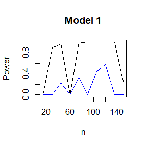

```r
k<-15
n<-k*(1:10) # Sample size
m<-99 # Times of permutation tests
B<-100 # Times of MC experiments
n0<-length(n)
pv1.dCor<-pv2.dCor<-pv1.ball<-pv2.ball<-numeric(n0) # Empirical power

for (i in n){
  x<-rmnorm(i,mean=rep(0,2),varcov=diag(1,2,2))
  e<-rmnorm(i,mean=rep(0,2),varcov=diag(1,2,2))
  y1<-x/4+e
  y2<-x/4*e
  z1<-cbind(x,y1)
  z2<-cbind(x,y2)

  p1.dCor<-p2.dCor<-p1.ball<-p2.ball<-numeric(B)
  for(j in 1:B){
  out1.dCor<-boot(z1,statistic=dCor,R=m,sim="permutation")
  out2.dCor<-boot(z2,statistic=dCor,R=m,sim="permutation")
  I1<-c(out1.dCor$t0,out1.dCor$t)
  I2<-c(out2.dCor$t0,out2.dCor$t)

  p1.dCor[j]<-mean(I1>=out1.dCor$t0)
  p2.dCor[j]<-mean(I2>=out2.dCor$t0)
  p1.ball[j]<-bcov.test(x,y1,R=m,seed=i*j)$p.value
  p2.ball[j]<-bcov.test(x,y2,R=m,seed=i*j)$p.value
  }

pv1.dCor[i/k]<-mean(p1.dCor<0.05)
pv2.dCor[i/k]<-mean(p2.dCor<0.05)
pv1.ball[i/k]<-mean(p1.ball<0.05)
pv2.ball[i/k]<-mean(p2.ball<0.05)
}

plot(n,pv1.dCor,xlab="n",ylab="Power",main="Model 1",type="l",ylim=c(0,1))
lines(n,pv1.ball,type="l",col="blue")
```

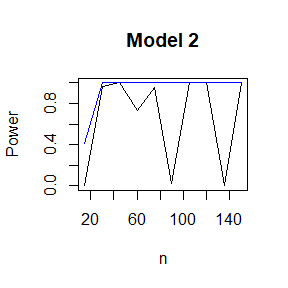

```r
plot(n,pv2.dCor,xlab="n",ylab="Power",main="Model 2",type="l",ylim=c(0,1))
lines(n,pv2.ball,type="l",col="blue")
```

Accoding to the result, corresponding conclusion can be drawn that:  
(1) For model 1, it can be seen that distance correlation test is more powerful.  
(2) For model 2, ball statistic test is globally (in terms of sample size $n$) powerful than distance correlation test.

# 2019-11-29

## 9.4

### (1) Basic idea

Target density:
$$f(x)=\frac{1}{2}e^{-|x|},\quad x\in R$$
Proposal density:
$$g(Y|X_t)=\frac{1}{\sqrt{2\pi\sigma^2}}e^{-\frac{(Y-X_t)^2}{2\sigma^2}},\quad t=1,\ldots$$
where $\sigma\in\{0.05,\ 0.5,\ 1,\ 5\}$ and $X_1$ is set to be $20$.

### (2) Code and output

```r
# Random walk Metropolis sampler
rw<-function(sigma,N){
  x<-numeric(N)
  u<-runif(N)
  x[1]<-20
  k<-0

  for (i in 2:N){
    y<-rnorm(1,x[i-1],sigma)

    if (u[i]<=(exp(-1*abs(y))/exp(-1*abs(x[i-1])))) {
      x[i]<-y
      k<-k+1
    }

    else x[i]<-x[i-1]
  }
  return(list(x=x,rate=k/N))
}

# Sampling from different sigma
sigma<-c(0.05,0.5,1,5)
N<-5000
x<-list(NULL)
length(x)<-4
rate<-numeric(4)
set.seed(111)
for (i in 1:4){
  out<-rw(sigma[i],N)
  x[[i]]<-out$x
  rate[i]<-out$rate
}

acc<-data.frame(sigma=sigma,Acceptance_rate=rate)
knitr::kable(acc)
```

| sigma | Acceptance_rate |
| --- | --- |
| 0.05 | 0.9822 |
| 0.50 | 0.8232 |
| 1.00 | 0.7072 |
| 5.00 | 0.2848 |

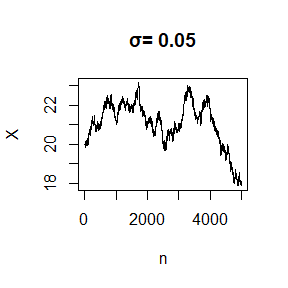

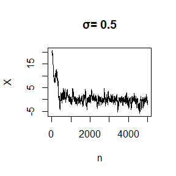

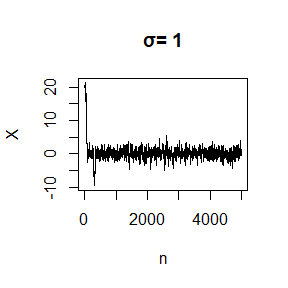

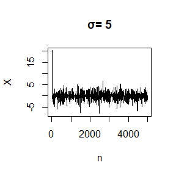

```r
for (i in 1:4) plot(1:N,x[[i]],type="l",xlab="n",ylab="X",main=paste("σ=",sigma[i]))
```

# 2019-12-6

## 11.1

For simplicity, fix $x\in\{2,\ 2.1,\ \ldots\ ,\ 3\}$ in the following answer.

```r
x<-seq(2,3,0.1)
y1<-log(exp(x))
y2<-exp(log(x))

all(y1==y2)
```

```
## [1] FALSE
```

```r
all.equal(y1,y2)
```

```
## [1] TRUE
```

The output substantiated that the equality of the two function doesn’t hold in computer arithmetic. On the contrary, it holds with near equality.

## 11.5

### (1) Code and output

```r
B<-function(a,k){
  g<-function(a,k){

    f<-function(u,k){
      f<-(k/(k+u^2))^(0.5*(k+1))
      return(f)
    }

    ck<-sqrt(a^2*k/(k+1-a^2))
    c<-2*exp(lgamma((k+1)/2)-lgamma(k/2))/sqrt(pi*k)
    I<-integrate(f,lower=0,upper=ck,k=k)$value
    g<-c*I
    return(g)
  }

  return(g(a,k-1)-g(a,k))
}

k<-as.integer(c(4:25,100,500,1000))
ak<-numeric(length(k))
for (i in 1:length(k)) ak[i]<-uniroot(B,lower=0.01,upper=2,k=k[i])$root
```

### (2) Comparison to 11.4

```r
A<-function(a,k){
  sk<-function(a,k){
    ck<-sqrt(a^2*k/(k+1-a^2))
    sk<-1-pt(ck,k)
  }
  A<-sk(a,k-1)-sk(a,k)
  return(A)
}

Ak<-numeric(length(k))
for (i in 1:length(k)) Ak[i]<-uniroot(A,c(0.01,sqrt(k[i]-0.01)),k=k[i])$root

out<-rbind(k,round(Ak,3),round(ak,3))
row.names(out)<-c("k","A(k)","a(k)")
out<-as.data.frame(out)
knitr::kable(out)
```

|  | V1 | V2 | V3 | V4 | V5 | V6 | V7 | V8 | V9 | V10 | V11 | V12 | V13 | V14 | V15 | V16 | V17 | V18 | V19 | V20 | V21 | V22 | V23 | V24 | V25 |
| --- | --- | --- | --- | --- | --- | --- | --- | --- | --- | --- | --- | --- | --- | --- | --- | --- | --- | --- | --- | --- | --- | --- | --- | --- | --- |
| k | 4.000 | 5.000 | 6.000 | 7.000 | 8.000 | 9.000 | 10.000 | 11.000 | 12.000 | 13.000 | 14.000 | 15.000 | 16.000 | 17.000 | 18.000 | 19.000 | 20.000 | 21.000 | 22.000 | 23.000 | 24.000 | 25.000 | 100.000 | 500.00 | 1000.000 |
| A(k) | 1.492 | 1.534 | 1.563 | 1.584 | 1.601 | 1.615 | 1.625 | 1.634 | 1.642 | 1.649 | 1.654 | 1.659 | 1.663 | 1.667 | 1.671 | 1.674 | 1.677 | 1.679 | 1.681 | 4.795 | 4.898 | 4.999 | 9.999 | 22.36 | 31.623 |
| a(k) | 1.492 | 1.534 | 1.563 | 1.584 | 1.601 | 1.615 | 1.625 | 1.634 | 1.642 | 1.649 | 1.654 | 1.659 | 1.663 | 1.667 | 1.671 | 1.674 | 1.677 | 1.679 | 1.681 | 1.684 | 1.686 | 1.687 | 1.721 | 1.73 | 1.731 |

## A-B-O blood type problem

### (1) Basic idea

1.Complete data likelihood
$$L(p,q,r;n_{AA},n_{BB},n_{OO},n_{AO},n_{BO},n_{AB})$$
$$=p^{2n_{AA}}q^{2n_{BB}}r^{2n_{OO}}(2pr)^{n_{AO}}(2qr)^{n_{BO}}(2pq)^{n_{nAB}}$$

2.Observed data log-likelihood
$$\log L(p,q,r;n_{AA},n_{BB},n_{OO},n_{AB},n_{A\cdot},n_{B\cdot})$$
$$=2n_{AA}\log p+2n_{BB}\log q+2n_{OO}\log r+(n_{A\cdot}-n_{AA})\log (2pr)+(n_{B\cdot}-n_{BB})\log (2qr)+n_{AB}log(2pq)$$

3.E-step
Notice that $r=1-p-q$, given $\hat{p}_t,\hat{q}_t$, we have:
$$E[l(p,q;n_{AA},n_{BB},n_{OO},n_{AB},n_{A\cdot},n_{B\cdot})|n_{OO},n_{AB},n_{A\cdot},n_{B\cdot}]$$
$$\begin{align}
=&\frac{2\hat{p}_t^2}{\hat{p}_t^2+2\hat{p}_t(1-\hat{p}_t-\hat{q}_t)}n_{A\cdot}\log p+\frac{2\hat{q}_t^2}{\hat{q}_t^2+2\hat{q}_t(1-\hat{p}_t-\hat{q}_t)}n_{B\cdot}\log q+2n_{OO}\log(1-p-q)\\
+&n_{A\cdot}\log (2p(1-p-q))-\frac{\hat{p}_t^2}{\hat{p}_t^2+2\hat{p}_t(1-\hat{p}_t-\hat{q}_t)}n_{A\cdot}\log (2p(1-p-q))\\
+&n_{B\cdot}\log (2q(1-p-q))-\frac{\hat{q}_t^2}{\hat{q}_0^2+2\hat{q}_t(1-\hat{p}_t-\hat{q}_t)}n_{B\cdot}\log (2q(1-p-q))\\
+&n_{AB}\log (2pq)
\end{align}$$

4.M-step  
Use function “optim” to find the maximizer of $l$, denoted as $(\hat{p}_{t+1},\hat{q}_{t+1})$

5.Iteraion

### (2) Code and output

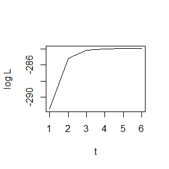

```r
l<-function(theta=numeric(2),pt,qt){
  na<-28;nb<-24;no<-41;nab<-70
  p<-theta[1]
  q<-theta[2]
  rt<-1-pt-qt
  c1<-pt^2/(pt^2+2*pt*rt)
  c2<-qt^2/(qt^2+2*qt*rt)

  l<-2*c1*na*log(p)+2*c2*nb*log(q)+2*no*log(1-p-q)+na*log(2*p*(1-p-q))-c1*na*log(2*p*(1-p-q))+nb*log(2*q*(1-p-q))-c2*nb*log(2*q*(1-p-q))+nab*log(2*p*q)
return(-l)
}

I<-1
lt<-numeric()
theta<-c(0.4,0.4)

while(I){
  theta0<-theta
  MLE<-optim(par=c(0.1,0.1),fn=l,pt=theta0[1],qt=theta0[2])
  theta<-MLE$par
  lt<-c(lt,-1*MLE$value)
  if(max(abs(theta0-theta))<1e-7) I<-0
}

theta.hat<-data.frame(p=theta[1],q=theta[2])
plot(1:length(lt),lt,xlab="t",ylab="log L",type="l")
```

```r
knitr::kable(theta.hat)
```

| p | q |
| --- | --- |
| 0.3273325 | 0.3104528 |

# 2019-12-13

## p.204 Exercise 3

```r
formulas<-list(
mpg~disp,
mpg~I(1/disp),
mpg~disp+wt,
mpg~I(1/disp)+wt
)

# for loops
n<-length(formulas)
fit3.loop<-list(NULL)
length(fit3.loop)<-n

for (i in 1:n) fit3.loop[[i]]<-lm(formulas[[i]],mtcars)

# lapply()
fit3.lapply<-lapply(formulas,function(x) lm(x,mtcars))

print(fit3.loop)
```

```
## [[1]]
##
## Call:
## lm(formula = formulas[[i]], data = mtcars)
##
## Coefficients:
## (Intercept)         disp
##    29.59985     -0.04122
##
##
## [[2]]
##
## Call:
## lm(formula = formulas[[i]], data = mtcars)
##
## Coefficients:
## (Intercept)    I(1/disp)
##       10.75      1557.67
##
##
## [[3]]
##
## Call:
## lm(formula = formulas[[i]], data = mtcars)
##
## Coefficients:
## (Intercept)         disp           wt
##    34.96055     -0.01772     -3.35083
##
##
## [[4]]
##
## Call:
## lm(formula = formulas[[i]], data = mtcars)
##
## Coefficients:
## (Intercept)    I(1/disp)           wt
##      19.024     1142.560       -1.798
```

```r
print(fit3.lapply)
```

```
## [[1]]
##
## Call:
## lm(formula = x, data = mtcars)
##
## Coefficients:
## (Intercept)         disp
##    29.59985     -0.04122
##
##
## [[2]]
##
## Call:
## lm(formula = x, data = mtcars)
##
## Coefficients:
## (Intercept)    I(1/disp)
##       10.75      1557.67
##
##
## [[3]]
##
## Call:
## lm(formula = x, data = mtcars)
##
## Coefficients:
## (Intercept)         disp           wt
##    34.96055     -0.01772     -3.35083
##
##
## [[4]]
##
## Call:
## lm(formula = x, data = mtcars)
##
## Coefficients:
## (Intercept)    I(1/disp)           wt
##      19.024     1142.560       -1.798
```

## p.204 Exercise 4

```r
bootprintaps <- lapply(1:10, function(i) {
rows <- sample(1:nrow(mtcars), rep = TRUE)
mtcars[rows, ]
})

n<-length(bootprintaps)

# for loops
fit4.loop<-list(NULL)
length(fit4.loop)<-n
for (i in 1:n) fit4.loop[[i]]<-lm(mpg~disp,data=bootprintaps[[i]])

# lapply()
fit4.lapply<-lapply(bootprintaps,function(x) lm(mpg~disp,data=x))

# lapply() without anonymous function
fit<-function(x) {
  out<-lm(mpg~disp,x)
  return(out)
}

fit4.named<-lapply(bootprintaps,fit)

print(fit4.loop)
```

```
## [[1]]
##
## Call:
## lm(formula = mpg ~ disp, data = bootprintaps[[i]])
##
## Coefficients:
## (Intercept)         disp
##    26.89063     -0.03158
##
##
## [[2]]
##
## Call:
## lm(formula = mpg ~ disp, data = bootprintaps[[i]])
##
## Coefficients:
## (Intercept)         disp
##    29.28597     -0.04104
##
##
## [[3]]
##
## Call:
## lm(formula = mpg ~ disp, data = bootprintaps[[i]])
##
## Coefficients:
## (Intercept)         disp
##    29.38898     -0.03968
##
##
## [[4]]
##
## Call:
## lm(formula = mpg ~ disp, data = bootprintaps[[i]])
##
## Coefficients:
## (Intercept)         disp
##    30.34025     -0.04675
##
##
```

[output cut: 43 more lines]

```
## lm(formula = mpg ~ disp, data = bootprintaps[[i]])
##
## Coefficients:
## (Intercept)         disp
##    30.56779     -0.04786
##
##
## [[10]]
##
## Call:
## lm(formula = mpg ~ disp, data = bootprintaps[[i]])
##
## Coefficients:
## (Intercept)         disp
##    27.98053     -0.03446
```

```r
print(fit4.lapply)
```

```
## [[1]]
##
## Call:
## lm(formula = mpg ~ disp, data = x)
##
## Coefficients:
## (Intercept)         disp
##    26.89063     -0.03158
##
##
## [[2]]
##
## Call:
## lm(formula = mpg ~ disp, data = x)
##
## Coefficients:
## (Intercept)         disp
##    29.28597     -0.04104
##
##
## [[3]]
##
## Call:
## lm(formula = mpg ~ disp, data = x)
##
## Coefficients:
## (Intercept)         disp
##    29.38898     -0.03968
##
##
## [[4]]
##
## Call:
## lm(formula = mpg ~ disp, data = x)
##
## Coefficients:
## (Intercept)         disp
##    30.34025     -0.04675
##
##
```

[output cut: 43 more lines]

```
## lm(formula = mpg ~ disp, data = x)
##
## Coefficients:
## (Intercept)         disp
##    30.56779     -0.04786
##
##
## [[10]]
##
## Call:
## lm(formula = mpg ~ disp, data = x)
##
## Coefficients:
## (Intercept)         disp
##    27.98053     -0.03446
```

```r
print(fit4.named)
```

```
## [[1]]
##
## Call:
## lm(formula = mpg ~ disp, data = x)
##
## Coefficients:
## (Intercept)         disp
##    26.89063     -0.03158
##
##
## [[2]]
##
## Call:
## lm(formula = mpg ~ disp, data = x)
##
## Coefficients:
## (Intercept)         disp
##    29.28597     -0.04104
##
##
## [[3]]
##
## Call:
## lm(formula = mpg ~ disp, data = x)
##
## Coefficients:
## (Intercept)         disp
##    29.38898     -0.03968
##
##
## [[4]]
##
## Call:
## lm(formula = mpg ~ disp, data = x)
##
## Coefficients:
## (Intercept)         disp
##    30.34025     -0.04675
##
##
```

[output cut: 43 more lines]

```
## lm(formula = mpg ~ disp, data = x)
##
## Coefficients:
## (Intercept)         disp
##    30.56779     -0.04786
##
##
## [[10]]
##
## Call:
## lm(formula = mpg ~ disp, data = x)
##
## Coefficients:
## (Intercept)         disp
##    27.98053     -0.03446
```

## p.204 Exercise 5

```r
rsq<-function(mod) summary(mod)$r.squared

model<-list(fit3.loop,fit3.lapply,fit4.loop,fit4.lapply,fit4.named)
rsquare<-lapply(model,function(x) lapply(x,rsq))

print(rsquare)
```

```
## [[1]]
## [[1]][[1]]
## [1] 0.7183433
##
## [[1]][[2]]
## [1] 0.8596865
##
## [[1]][[3]]
## [1] 0.7809306
##
## [[1]][[4]]
## [1] 0.8838038
##
##
## [[2]]
## [[2]][[1]]
## [1] 0.7183433
##
## [[2]][[2]]
## [1] 0.8596865
##
## [[2]][[3]]
## [1] 0.7809306
##
## [[2]][[4]]
## [1] 0.8838038
##
##
## [[3]]
## [[3]][[1]]
## [1] 0.6593321
##
## [[3]][[2]]
## [1] 0.7398154
##
## [[3]][[3]]
## [1] 0.651476
##
## [[3]][[4]]
## [1] 0.7850596
```

[output cut: 67 more lines]

```
##
## [[5]][[6]]
## [1] 0.7549664
##
## [[5]][[7]]
## [1] 0.6611554
##
## [[5]][[8]]
## [1] 0.6918991
##
## [[5]][[9]]
## [1] 0.7509602
##
## [[5]][[10]]
## [1] 0.7407016
```

## p.214 Exercise 3

```r
trials <- replicate(
100,
t.test(rpois(10, 10), rpois(7, 10)),
simplify = FALSE
)

p.value<-sapply(trials, function(x) x$p.value)

# Extra answer
p.extra<-sapply(trials,"[[","p.value")

print(p.value)
```

```
##   [1] 0.200836746 0.245123641 0.852744087 0.273557460 0.270730350 0.679201689
##   [7] 0.070024709 0.104319604 0.356578125 0.092627819 0.724787033 0.094210496
##  [13] 0.372187739 0.285201289 0.587994379 0.907977872 0.616601104 0.668651792
##  [19] 0.828357346 0.949270021 0.918928703 0.723265922 0.413778449 0.307190493
##  [25] 0.536102365 0.870082704 0.377623228 0.956711455 0.034992166 0.014152342
##  [31] 0.064941430 0.517088119 0.007323518 0.863697014 0.760789506 0.995171294
##  [37] 0.122870354 0.200164876 0.722819267 0.988238706 0.710795570 0.381533129
##  [43] 0.529668565 0.917570725 0.893040421 0.406581736 0.474557635 0.095234668
##  [49] 0.452578560 0.394861072 0.982962414 0.759885613 0.316184952 0.711235140
##  [55] 0.491334613 0.321299129 0.510750643 0.398690738 0.230428647 0.852977976
##  [61] 0.907440280 0.211776120 0.952187053 0.310155274 0.530621918 0.378312835
##  [67] 0.688123561 0.932175022 0.700080517 0.355316531 0.298281722 0.969770407
##  [73] 0.144771722 0.193304711 0.127176690 0.904741630 0.792255135 0.883822250
##  [79] 0.220724353 0.413733045 0.334979171 1.000000000 0.919964130 0.733374445
##  [85] 0.323586524 0.221786600 0.864300804 0.962196765 0.206297960 0.228569014
##  [91] 0.701583394 0.380377965 0.329664571 0.704033535 0.918030124 0.923001375
##  [97] 0.708198850 0.821952976 0.141769406 0.058115427
```

```r
print(p.extra)
```

```
##   [1] 0.200836746 0.245123641 0.852744087 0.273557460 0.270730350 0.679201689
##   [7] 0.070024709 0.104319604 0.356578125 0.092627819 0.724787033 0.094210496
##  [13] 0.372187739 0.285201289 0.587994379 0.907977872 0.616601104 0.668651792
##  [19] 0.828357346 0.949270021 0.918928703 0.723265922 0.413778449 0.307190493
##  [25] 0.536102365 0.870082704 0.377623228 0.956711455 0.034992166 0.014152342
##  [31] 0.064941430 0.517088119 0.007323518 0.863697014 0.760789506 0.995171294
##  [37] 0.122870354 0.200164876 0.722819267 0.988238706 0.710795570 0.381533129
##  [43] 0.529668565 0.917570725 0.893040421 0.406581736 0.474557635 0.095234668
##  [49] 0.452578560 0.394861072 0.982962414 0.759885613 0.316184952 0.711235140
##  [55] 0.491334613 0.321299129 0.510750643 0.398690738 0.230428647 0.852977976
##  [61] 0.907440280 0.211776120 0.952187053 0.310155274 0.530621918 0.378312835
##  [67] 0.688123561 0.932175022 0.700080517 0.355316531 0.298281722 0.969770407
##  [73] 0.144771722 0.193304711 0.127176690 0.904741630 0.792255135 0.883822250
##  [79] 0.220724353 0.413733045 0.334979171 1.000000000 0.919964130 0.733374445
##  [85] 0.323586524 0.221786600 0.864300804 0.962196765 0.206297960 0.228569014
##  [91] 0.701583394 0.380377965 0.329664571 0.704033535 0.918030124 0.923001375
##  [97] 0.708198850 0.821952976 0.141769406 0.058115427
```

## p.214 Exercise 7

### (1) Basic idea

* As mclapply is not available in Windows, I resort to the function “parSapply” in package parallel, a multicore version of sapply.
* However, as vapply prefix the characteristic of output, when doing parallel computation, inputs are allocated into different cores to conduct calculation. Thus so-called “mcvapply” can’t be implemented.
Take a simple example to illuprintate that:
$$f=\operatorname{function}(x)\ x+1,\\ x_0=\operatorname{c}(1,2,3).$$
If you want to calculateand f(x_0), and allocate the calculation to 2 cores, then there’s no way to prefix the proper argument: FUN.VALUE for vapply because the allocation is randomly done. For instance, numeric(1), numeric(2), numeric(3) will all render error warning.

* In the following answer, mcsapply() are implemented to do random sampling.

### (2) Code and uotput

```r
library(parallel)
nc<-detectCores()
cl<-makeCluster(2)

n<-1:10000
fun<-function(n) sample(1:n,n,replace=T)

# mcsapply
mcsapply<-function(x,f) parSapply(cl,x,f)

# Compare runtime
system.time(mcsapply(n,fun))
```

```
## 用户 系统 流逝
## 1.05 0.22 4.25
```

```r
system.time(sapply(n,fun))
```

```
## 用户 系统 流逝
## 3.39 0.13 3.53
```

```r
stopCluster(cl)
```